# R for Data Science

##### Filtering Joins

Filter rows. You specify columns in two tables (we’ll call them table_A and table_B). If a row’s value in a specified column in table_A matches a value in a specified column in table_B, then that row in table_A is included in a new DF (or excluded depending on the function).

Filtering joins do not combine variables like mutating joins. Because of this, the type of relations between tables does not matter. You can have 1-1, 1-n, or n-n relations. You will not get ambiguous results with n-n because you are not actually attaching variables. I.e. you do not need to have a primary key column.

[output not shown]

**semi_join() Simple Example**

```r
table_fruits <- tribble(
  ~fruit_id,  ~fruit_name, ~color_id,
     "F1", "Strawberry", "C1",
     "F2", "Cherry", "C1",
     "F3", "Banana", "C3",
     "F4", "Blueberry", "C5"
)

table_colors <- tribble(
  ~id, ~color_name,
     "C1", "Red",
     "C2", "Purple",
     "C3", "Yellow"
)

# Using semi_join()
semi_join(
  table_fruits,
  table_colors,
  by = c("color_id" = "id")
)
```

```
#> # A tibble: 3 x 3
#>   fruit_id fruit_name color_id
#>   <chr>    <chr>      <chr>
#> 1 F1       Strawberry C1
#> 2 F2       Cherry     C1
#> 3 F3       Banana     C3
```

```r
# Using filter()
filter(
  table_fruits,
  (color_id %in% table_colors$id)
)
```

```
#> # A tibble: 3 x 3
#>   fruit_id fruit_name color_id
#>   <chr>    <chr>      <chr>
#> 1 F1       Strawberry C1
#> 2 F2       Cherry     C1
#> 3 F3       Banana     C3
```

**semi_join() Complicated Example**

Instead of specifying one column in each table, you can specify multiple. R then matches rows only if they have the right combination of values. Matches are included in a new table. Same idea as compound/concatenated/composite keys. You can see how using `filter()` becomes a pain when doing this as you can not simply use the `%in%` operator.

```r
top_3 <- group_by(flights, year, month, day) %>%
  summarize(flights_by_day = n()) %>%
  arrange(desc(flights_by_day)) %>%
  head(3)

top_3
```

```
#> # A tibble: 3 x 4
#> # Groups:   year, month [2]
#>    year month   day flights_by_day
#>   <int> <int> <int>          <int>
#> 1  2013    11    27           1014
#> 2  2013     7    11           1006
#> 3  2013     7     8           1004
```

```r
# Using semi_join()
semi_join(
  flights,
  top_3,
  by = c("year" = "year", "month" = "month", "day" = "day")
)
```

```
#> # A tibble: 3,024 x 19
#>     year month   day dep_time sched_dep_time dep_delay arr_time sched_arr_time
#>    <int> <int> <int>    <int>          <int>     <dbl>    <int>          <int>
#>  1  2013    11    27       28           1930       298      129           2049
#>  2  2013    11    27      505            500         5      703            651
#>  3  2013    11    27      514            515        -1      743            808
#>  4  2013    11    27      535            540        -5      907            850
#>  5  2013    11    27      540            545        -5      815            835
#>  6  2013    11    27      551            600        -9      920            854
#>  7  2013    11    27      551            600        -9      918            849
#>  8  2013    11    27      554            600        -6      719            719
#>  9  2013    11    27      554            600        -6      707            717
#> 10  2013    11    27      554            600        -6      907            846
#> # ... with 3,014 more rows, and 11 more variables: arr_delay <dbl>,
#> #   carrier <chr>, flight <int>, tailnum <chr>, origin <chr>, dest <chr>,
#> #   air_time <dbl>, distance <dbl>, hour <dbl>, minute <dbl>, time_hour <dttm>
```

```r
# Using filter() becomes a pain
filter(
  flights,
  (year == 2013 & month == 11 & day == 27) |
  (year == 2013 & month == 7 & day == 11) |
  (year == 2013 & month == 7 & day == 8)
)
```

```
#> # A tibble: 3,024 x 19
#>     year month   day dep_time sched_dep_time dep_delay arr_time sched_arr_time
#>    <int> <int> <int>    <int>          <int>     <dbl>    <int>          <int>
#>  1  2013    11    27       28           1930       298      129           2049
#>  2  2013    11    27      505            500         5      703            651
#>  3  2013    11    27      514            515        -1      743            808
#>  4  2013    11    27      535            540        -5      907            850
#>  5  2013    11    27      540            545        -5      815            835
#>  6  2013    11    27      551            600        -9      920            854
#>  7  2013    11    27      551            600        -9      918            849
#>  8  2013    11    27      554            600        -6      719            719
#>  9  2013    11    27      554            600        -6      707            717
#> 10  2013    11    27      554            600        -6      907            846
#> # ... with 3,014 more rows, and 11 more variables: arr_delay <dbl>,
#> #   carrier <chr>, flight <int>, tailnum <chr>, origin <chr>, dest <chr>,
#> #   air_time <dbl>, distance <dbl>, hour <dbl>, minute <dbl>, time_hour <dttm>
```

```r
# Using filter() wrongly
# Should not use %in% when multiple columns have to match in specific combination
filter(
  flights,
  (year %in% top_3$year) &
  (month %in% top_3$month) &
  (day %in% top_3$day)
)
```

```
#> # A tibble: 5,804 x 19
#>     year month   day dep_time sched_dep_time dep_delay arr_time sched_arr_time
#>    <int> <int> <int>    <int>          <int>     <dbl>    <int>          <int>
#>  1  2013    11     8      457            500        -3      654            651
#>  2  2013    11     8      524            515         9      809            808
#>  3  2013    11     8      537            545        -8      839            835
#>  4  2013    11     8      540            545        -5      843            855
#>  5  2013    11     8      550            600       -10      648            658
#>  6  2013    11     8      551            600        -9      648            701
#>  7  2013    11     8      553            600        -7      810            810
#>  8  2013    11     8      553            600        -7      808            827
#>  9  2013    11     8      554            600        -6      716            719
#> 10  2013    11     8      554            600        -6     1032           1043
#> # ... with 5,794 more rows, and 11 more variables: arr_delay <dbl>,
#> #   carrier <chr>, flight <int>, tailnum <chr>, origin <chr>, dest <chr>,
#> #   air_time <dbl>, distance <dbl>, hour <dbl>, minute <dbl>, time_hour <dttm>
```

**anti_join() Simple Example**

```r
table_fruits <- tribble(
  ~fruit_id,  ~fruit_name, ~color_id,
     "F1", "Strawberry", "C1",
     "F2", "Cherry", "C1",
     "F3", "Banana", "C3",
     "F4", "Blueberry", "C5"
)

table_colors <- tribble(
  ~id, ~color_name,
     "C1", "Red",
     "C2", "Purple",
     "C3", "Yellow"
)

anti_join(
  table_fruits,
  table_colors,
  by = c("color_id" = "id")
)
```

```
#> # A tibble: 1 x 3
#>   fruit_id fruit_name color_id
#>   <chr>    <chr>      <chr>
#> 1 F4       Blueberry  C5
```

##### Set Operations

Set operations are used less frequently then mutating joins and filtering joins. Probably never use these. Used to break a single complex filter into simpler pieces. Requires that each table have the same variables. Treats each table as a set and each row as an element of the set. See Logical/Boolean Operators for image of set operations.

| Function | Use |
| --- | --- |
| `intersect()` | Same Boolean logic as AND (&) |
| `union()` | Same Boolean logic as OR (\|) |
| `setdiff()` | A but not B. |

```r
table_A <- tribble(
  ~column_x, ~column_y,
  1, 1,
  2, 1
)

table_B <- tribble(
  ~column_x, ~column_y,
  1, 1,
  1, 2
)
```

**intersect()**

```r
intersect(table_A, table_B)
```

```
#> # A tibble: 1 x 2
#>   column_x column_y
#>      <dbl>    <dbl>
#> 1        1        1
```

**union()**

```r
union(table_A, table_B)
```

```
#> # A tibble: 3 x 2
#>   column_x column_y
#>      <dbl>    <dbl>
#> 1        1        1
#> 2        2        1
#> 3        1        2
```

**setdiff()**

```r
setdiff(table_A, table_B)
```

```
#> # A tibble: 1 x 2
#>   column_x column_y
#>      <dbl>    <dbl>
#> 1        2        1
```

### stringr Package

- Check out the stringr Cheat Sheet
- The stringr package contains tools for working with string data…r
- stringr has about 50 functions, most of which start with `str_`
- stringr is a subset of the stringi package
- stringi has about 250 functions, most of which start with `stri_`
- stringr contains the most used functions for working with strings but you can use stringi if you don’t find what you need in stringr
- stringr contains example data to work with including `fruit`, `sentences`, and `stringr-data`
- Some functions take a `locale =` argument where you can specify which language you want to use. The default is `locale = "en"`.
- **Regular expressions**—are specified patterns of characters that are compared to another string. Matches between the search pattern and the string are returned. Regular expressions may use many special symbols to add logic to the search. Multiple functions use regular expressions, but differ in what they do once they find a match. Some find all matches while others stop after finding the first match in a string. Some return TRUE for each match, some return a word containing the matched pattern, some replace the matched pattern with other characters, and others split a string at the match.
- Below are a few examples of stringr functions. The rest can be looked up in the stringr package index.

[output not shown]

**str_length()**

```r
str_length("Hello world")
```

```
#> [1] 11
```

```r
str_length(c("a", "Hello world", NA))
```

```
#> [1]  1 11 NA
```

**str_c()**

```r
str_c("Hello", " ", "world")
```

```
#> [1] "Hello world"
```

```r
str_c("Hello", "world", sep = " " )
```

```
#> [1] "Hello world"
```

**str_sub()**

```r
my_string <- c("Banana", "Avocado", "Mango")
str_sub(my_string, 1, 3)
```

```
#> [1] "Ban" "Avo" "Man"
```

**str_sort()**

```r
my_string <- c("Banana", "Avocado", "Mango", "mango")
str_sort(my_string)
```

```
#> [1] "Avocado" "Banana"  "mango"   "Mango"
```

**str_view_all()**

```r
my_string <- c("Banana", "Avocado", "Mango")
str_view_all(my_string, "an")
```

[interactive chart not shown]

**str_view_all() Using a RegEx Symbol**

`.` means any character can be in this position in the pattern.

```r
my_string <- c("Banana", "Avocado", "Mango")
str_view_all(my_string, ".o")
```

[interactive chart not shown]

### glue Package

- Check out the [glue website](https://glue.tidyverse.org/)
- The glue package contains tools for working with strings
- glue is not part of the core tidyverse and needs to be imported separately

| Function | Use |
| --- | --- |
| `glue()` | Allows you to embed R expressions inside curly braces inside strings. Includes other helpful features as well. |

**Embed Text Expression**

```r
name <- "Bender"
glue("Hello {name}")
```

```
#> Hello Bender
```

**Embed Math Expression**

```r
a <- 10
glue("I am {100-a} years old")
```

```
#> I am 90 years old
```

**Break Up Long String to Avoid Scrolling Right**

```r
"This is a long string.  This is a long string.  This is a long string.  This is a long string."
```

```
#> [1] "This is a long string.  This is a long string.  This is a long string.  This is a long string."
```

```r
glue('This is a long string. ',
     'This is a long string. ',
     'This is a long string. ',
     'This is a long string')
```

```
#> This is a long string. This is a long string. This is a long string. This is a long string
```

### forcats Package

- Check out the forcats Cheat Sheet
- The forcats package contains tools for working with factors
- I.e. **for cat**egorical variables
- “(and it’s an anagram of factors!)”
- Here are a few example functions

[output not shown]

**fct_c()**

```r
my_fact_1 <- factor(c("a", "b", "b"))
my_fact_2 <- factor(c("c", "c"))
my_fact_3 <- fct_c(my_fact_1, my_fact_2)
my_fact_3
```

```
#> [1] a b b c c
#> Levels: a b c
```

**fct_recode()**

Correct month names

```r
my_factor <- factor(
  c("Ja", "Fe", "Au", "Ma")
)

my_fac_rec <- fct_recode(my_factor, Jan = "Ja", Feb = "Fe", Aug = "Au", Mar = "Ma")
my_fac_rec
```

```
#> [1] Jan Feb Aug Mar
#> Levels: Aug Feb Jan Mar
```

**fct_expand()**

Add missing months as levels. Months that already exist will be ignored.

```r
all_months <- c(
    "Jan", "Feb", "Mar", "Apr", "May", "Jun",
    "Jul", "Aug", "Sep", "Oct", "Nov", "Dec"
  )

my_fac_exp <- fct_expand(my_fac_rec, all_months)
my_fac_exp
```

```
#> [1] Jan Feb Aug Mar
#> Levels: Aug Feb Jan Mar Apr May Jun Jul Sep Oct Nov Dec
```

**fct_relvel()**

Re-order months so they go by the calendar

```r
all_months <- c(
    "Jan", "Feb", "Mar", "Apr", "May", "Jun",
    "Jul", "Aug", "Sep", "Oct", "Nov", "Dec"
  )

my_fac_rel <- fct_relevel(my_fac_exp, all_months)
my_fac_rel
```

```
#> [1] Jan Feb Aug Mar
#> Levels: Jan Feb Mar Apr May Jun Jul Aug Sep Oct Nov Dec
```

### lubridate Package

- Check out the lubridate Cheat Sheet
- The lubridate package contains tools for working with dates and times
- lubridate is not part of the core tidyverse and needs to be imported separately

#### Create Date and Time Data

If your date-time data is not stored in the `<date>`, `<time>`, or `<dttm>` format you need, you can create this data from:

1. A string. The lubridate package has many functions to parse dates from strings. E.g. `ymd_hms()`. This stands for “year”, “month”, “day”, “hours”, “minutes”, “seconds”. There are many of these functions with different arrangements. E.g. `mdy()`. They take in strings as well as unquoted integers
2. Individual date/time components. When date/time components are stored in separate columns in a table you can use `mutate()` to create a new column. Within `mutate()` you can use `make_date()` or `make_datetime()` to select which columns to combine.
3. Another date/time format

| Function | Use |
| --- | --- |
| `today()` | Returns current `<date>` |
| `now()` | Returns current `<dttm>` |
| `ymd_hms()` | Parses `<dttm>` data from string or integer data. Many similar functions. |
| `make_date()` | Returns `<date>` from multiple columns in a DF |
| `make_datetime()` | Returns `<dttm>` from multiple columns in a DF |

**today()**

```r
today()
```

```
#> [1] "2021-12-21"
```

**now()**

```r
now()
```

```
#> [1] "2021-12-21 09:17:16 PST"
```

**ymd_hms()**

```r
my_str <- "2021-06-03 09:56:18"
ymd_hms(my_str)
```

```
#> [1] "2021-06-03 09:56:18 UTC"
```

```r
my_int <- 20210603095618
ymd_hms(my_int)
```

```
#> [1] "2021-06-03 09:56:18 UTC"
```

**make_datetime()**

```r
select(flights, year, month, day, hour, minute) %>%
  mutate(departure_time = make_datetime(year, month, day, hour, minute))
```

```
#> # A tibble: 336,776 x 6
#>     year month   day  hour minute departure_time
#>    <int> <int> <int> <dbl>  <dbl> <dttm>
#>  1  2013     1     1     5     15 2013-01-01 05:15:00
#>  2  2013     1     1     5     29 2013-01-01 05:29:00
#>  3  2013     1     1     5     40 2013-01-01 05:40:00
#>  4  2013     1     1     5     45 2013-01-01 05:45:00
#>  5  2013     1     1     6      0 2013-01-01 06:00:00
#>  6  2013     1     1     5     58 2013-01-01 05:58:00
#>  7  2013     1     1     6      0 2013-01-01 06:00:00
#>  8  2013     1     1     6      0 2013-01-01 06:00:00
#>  9  2013     1     1     6      0 2013-01-01 06:00:00
#> 10  2013     1     1     6      0 2013-01-01 06:00:00
#> # ... with 336,766 more rows
```

#### Date and Time Components

Above, we combined date and time components. We can also extract them separately, update them, and round date-time components.

| Function | Use |
| --- | --- |
| `year()` | Returns year |
| `month()` | Returns month. Can set `label = TRUE` to return abbreviated name of month |
| `wday()` | Returns day of the week. Can set `label = TRUE` to return abbreviated name of day |
| `day()` | Returns day of the month |
| `mday()` | Same as `day()` |
| `yday()` | Returns day of the year (doesn’t reset count each month) |
| `hour()` | Returns hour |
| `minute()` | Returns minute |
| `second()` | Returns second |
| `update()` | Returns new date/time item with updated values |
| `round_date()` | Returns date-time data rounded to nearest specified time unit (year, month, etc.) |
| `floor_date()` | Same as `round_date()` but always rounds down |
| `ceiling_date()` | Same as `round_date()` but always rounds up |

**Extract Date and Time Components**

```r
my_dttm <- ymd_hms("2021-06-03 09:56:18")

year(my_dttm)
```

```
#> [1] 2021
```

```r
(year(my_dttm) <- 1999)
```

```
#> [1] 1999
```

```r
month(my_dttm, label = TRUE)
```

```
#> [1] Jun
#> 12 Levels: Jan < Feb < Mar < Apr < May < Jun < Jul < Aug < Sep < ... < Dec
```

```r
wday(my_dttm, label = TRUE)
```

```
#> [1] Thu
#> Levels: Sun < Mon < Tue < Wed < Thu < Fri < Sat
```

```r
mday(my_dttm)
```

```
#> [1] 3
```

```r
yday(my_dttm)
```

```
#> [1] 154
```

```r
hour(my_dttm)
```

```
#> [1] 9
```

```r
minute(my_dttm)
```

```
#> [1] 56
```

```r
second(my_dttm)
```

```
#> [1] 18
```

**update()**

```r
my_dttm <- ymd_hms("2021-06-03 09:56:18")

new_dttm <- update(my_dttm, year = 1999)
new_dttm
```

```
#> [1] "1999-06-03 09:56:18 UTC"
```

#### Time Spans

There are three ways to measure time spans:

1. **Durations**—create time span by specifying number of seconds. Can be used with arithmetic operators and date-time data.
   1. E.g. add 1 hour onto an existing `<dttm>`.
2. **Periods**—create time span in human units like days, weeks, and months. Can be used with arithmetic operators and date-time data. Accounts for leap years and daylight saving time in more intuitive way than durations.
   1. E.g. if you add 5 years onto Jan 1st, the date will still be Jan 1st 5 years later and not Dec 31st (accounts for leap year)
3. **Intervals**—calculate time span by specifying starting and ending point.

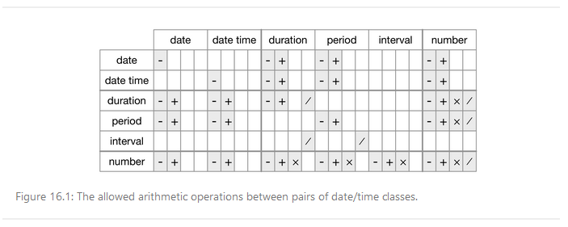

| Function | Use |
| --- | --- |
| `as.duration()` | Takes a difftime object and converts it to duration in seconds. Always uses seconds. |
| `dseconds()` | Creates duration in seconds, with input of seconds. Always outputs in seconds. |
| `d<TIMECHUNK>()` | You can also input minutes, hours, days, weeks, and years. Not months though as they have different lengths. Always outputs in seconds. |
| `seconds()` | Creates period in seconds |
| `<TIMECHUNK>()` | Can also input minutes, hours, seconds, days, weeks, months, and years to return a period |
| `%--%` | Operator used to signify intervals |
| `%/%` | Operator used in integer division. Used in intervals. |

**as.duration()**

```r
my_age <- today() - mdy(07151991)
as.duration(my_age)
```

```
#> [1] "960508800s (~30.44 years)"
```

#### Time Zones

The names of times zones often change and are not unique. E.g. EST could be for the US, Canada, or Australia. For these reasons time zones are usually specified with the **IANA** standard. With IANA a time zone consists of `"<CONTINENT>/<CITY>"`. Continent names and city names are used as country names often change. - E.g. “America/New_York”

You can change a time zone in two ways:

1. Keep the time numbers the same but change the time zone name. The two times+time zones represent different instances in time. Use this if time zone was mislabeled.
   1. E.g. 12 PM “America/Los_Angeles” to 12 PM “America/New_York”
2. Change the time numbers and change the time zone names. The two times+time zones represent the same instance in time. Use for time conversions between time zones.
   1. E.g. 12 PM “America/Los_Angeles” to 3 PM “America/New_York”

| Function | Use |
| --- | --- |
| `Sys.timezone()` | Return R’s best guess as to current time zone |
| `OlsonNames()` | Returns list of all time zone names |
| `force_tz()` | Returns new instance in time. This would correct mislabeled time zone. |
| `with_tz()` | Returns same instance in time, converting time to different time zone |

**Sys.timezone()**

```r
Sys.timezone()
```

```
#> [1] "America/Los_Angeles"
```

**OlsonNames()**

```r
length(OlsonNames())
```

```
#> [1] 593
```

**force_tz()**

```r
wrong_tz <- ymd_hms("2021-06-03 12:00:00", tz = "America/Los_Angeles")
right_tz <- force_tz(wrong_tz, tzone = "America/New_York")
right_tz
```

```
#> [1] "2021-06-03 12:00:00 EDT"
```

**with_tz()**

```r
my_PT <- ymd_hms("2021-06-03 12:00:00", tz = "America/Los_Angeles")
my_ET <- with_tz(my_PT, tz = "America/New_York")
my_ET
```

```
#> [1] "2021-06-03 15:00:00 EDT"
```

## Visulize Data

### Built-in Functions

[output not shown]

**plot() Point Graph**

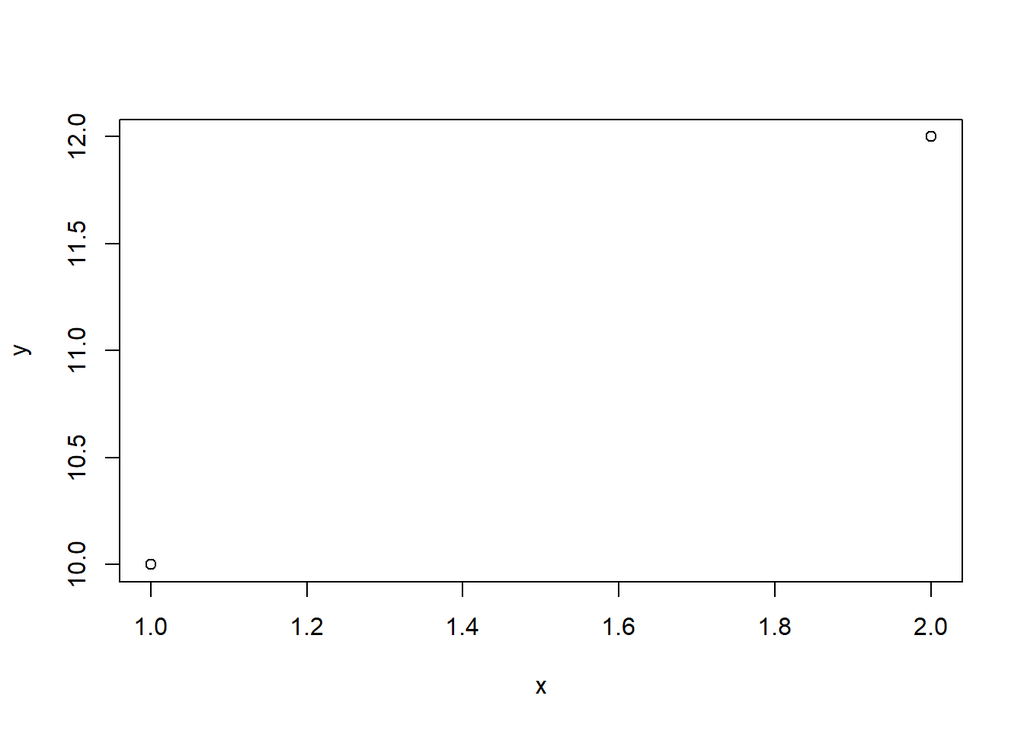

```r
x <- c(1,2)
y <- c(10, 12)
plot(x,y)
```

**plot() Line Graph**

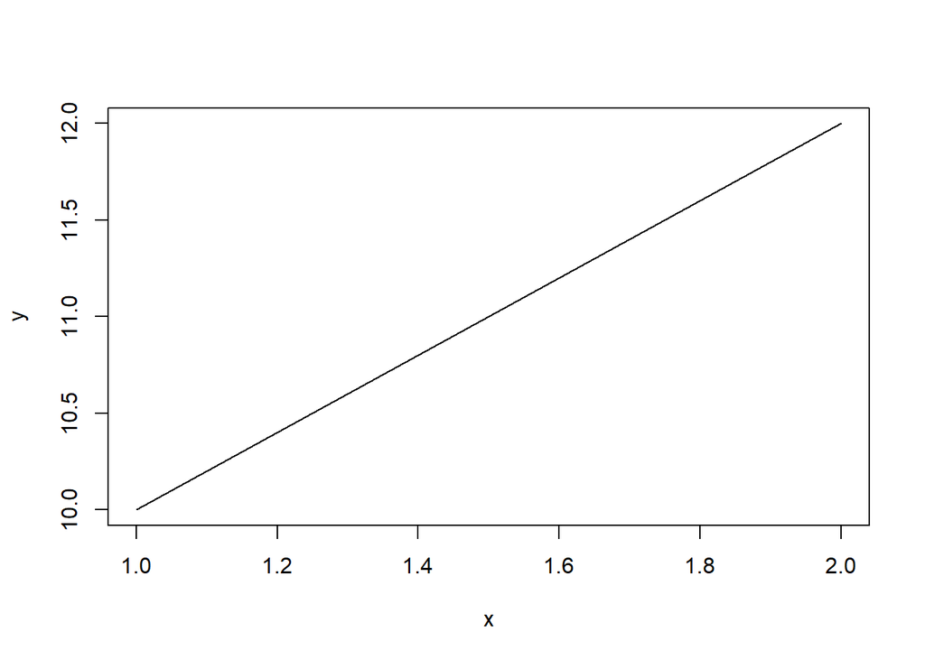

```r
x <- c(1,2)
y <- c(10, 12)
plot(x,y,type = "l")
```

**pie() Chart**

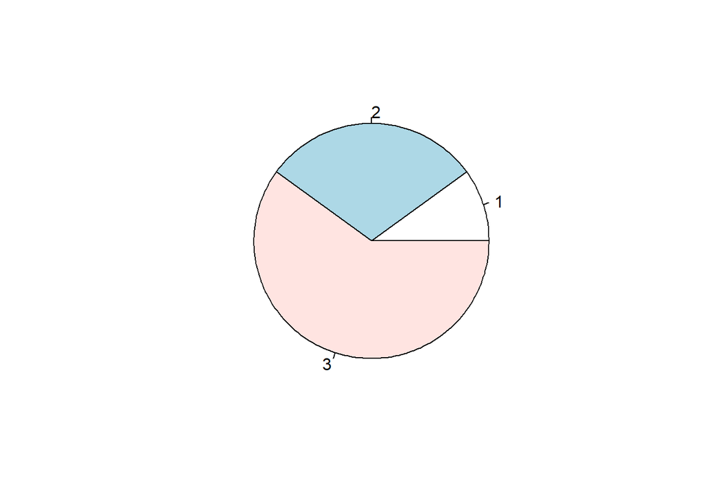

```r
x <- c(10, 30, 60)
pie(x)
```

**barplot()**

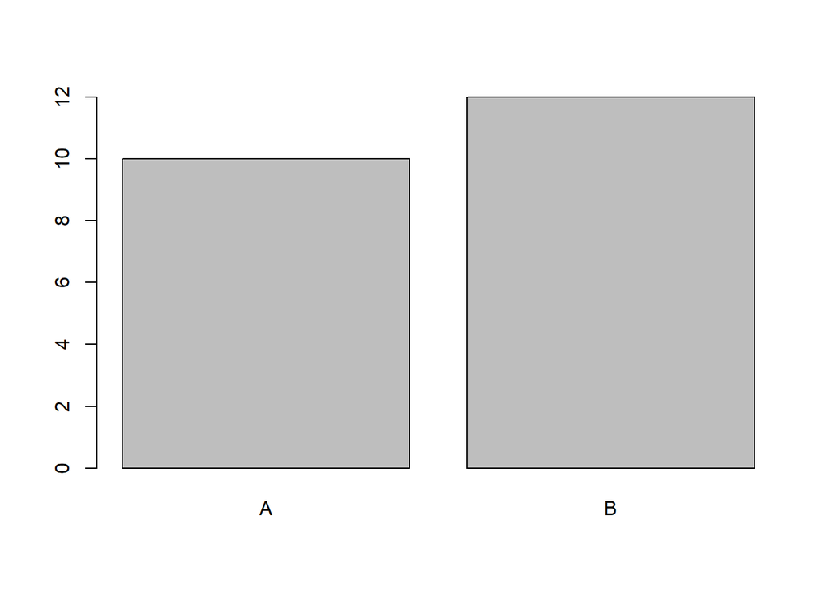

```r
x <- c("A", "B")
y <- c(10, 12)
barplot(y, names.arg = x)
```

### ggplot2 Package

- Check out the ggplot2 Cheat Sheet
- Check out the [ggplot2 reference page](https://ggplot2.tidyverse.org/reference/)
- Check out the *R Graphics Cookbook*
- Check out the *ggplot2: Elegant Graphics for Data*
- The ggplot2 package contains tools for making pretty plots
- Though I’d like to think ‘gg’ stands for **G**ood **G**ame’, it actually stands for *The **G**rammar of **G**raphics*, which is a book on data visualization. The book gives terms to all components of a graphic and describes them. The goal is to be able to break a graphic up into parts, customize each part, and put it back together.
- There are extensions available that may help with specific tasks. Found here: https://exts.ggplot2.tidyverse.org/gallery/.

#### Grammar

Grammar parts include:

1. **`<DATA>`**—data set. Required.
2. **`<GEOM_FUNCTION>`**—visual object used to represent values. Required. E.g. point, line, bar, histogram, etc.. Over 40 available. Each visual object is said to be in its own **layer**. You can have multiple visual objects in the same graph by creating multiple **layers**.
3. **`<MAPPINGS>`**—assign variables to x axis and usually y axis. Required. May assign other variables to control aesthetic properties of visual object like color, shape, size, etc..
4. **`<STAT>`**—short for statistical transformation. Builds a new variable to plot. Over 20 available. Each geometry has a default stat. You can type in a new stat to use, which is helpful if you want to override the default, or simply draw attention to the default. E.g. counting records in a group to build a bar chart/histogram.

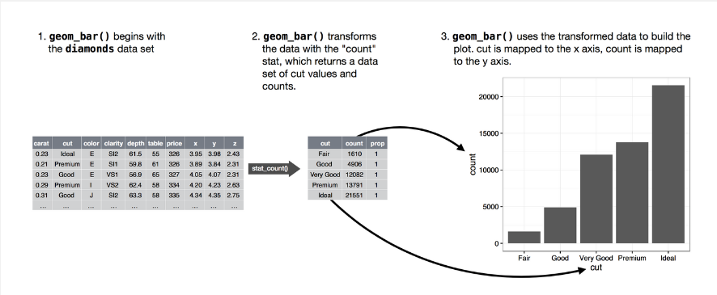

5. **`<POSITION>`**—control position of visual objects that would otherwise overlap. Not required as each geometry type has a default position. About 10 positions. Common ones include: “identity”, “dodge”, “stack”, “fill”, and “jitter”.
6. **`<COORDINATE_FUNCTION>`**—determines how the x and y aesthetics combine to position elements in the plot.0
7. **`<FACET_FUNCTION>`**—subplot that shows a subset of dataset. You select a variable (needs to be categorical/discrete) whose different categories are used split up your data into groups.
8. **`<SCALE_FUNCTION>`**—controls scale of axes. How axes are broken up and labeled. Also changes other symbology and the legend.
9. **`<LABEL_FUNCTION>`**—control labels of plot, caption, axes names. Annotations control labels of visual objects3
10. **`<THEME_FUNCTION>`**—control the display of all non-data elements of the plot

Use the `ggplot()` function and the following syntax. Replace items inside <> with own R code. Note that you can omit the word before the `=` and the `=`, and the code still runs. More clear if you include all the syntax text though.

```
ggplot(data = <DATA>) +
  <GEOM_FUNCTION>(
  mapping = aes(<MAPPINGS>),
  stat = <STAT>,
  position = <POSITION>
  ) +
  <COORDINATE_FUNCTION> +
  <FACET_FUNCTION> +
  <SCALE_FUNCTION> +
  <Label_FUNCTION> +
  <THEME_FUNCTION>
```